# Creating a Content Recommendation Engine with R, OpenCPU and GTM

6 March 2016

## Building Blocks

## Intro to R

[figure not shown]

- Statistical programming language
- 2 million users. 40% increase last year
- Open Source = lots of cool libraries
- Libraries to collect, mung, visualise, machine learning, stats, etc. etc.
- [Using R in a digital analytics workflow](https://rpubs.com/MarkeD/r-in-digital-analytics-workflow) - my first Measurecamp presentation

## Intro to OpenCPU

[figure not shown]

- RaaS - R as a Service
- [An API for embedded scientific computing](https://www.opencpu.org/)
- Turn R code into JSON
- Supporting JavaScript library
- A server that creates a RESTful web API
- Let R programmers create the models, front-end web developers handle the data
- See also: www.yhat.com and www.dominodatalab.com and [Plumber](http://plumber.trestletech.com/)

## Intro to Google Tag Manager

[figure not shown]

- Free [tag management system](https://www.google.com/analytics/tag-manager/) on Google infrastructure
- JavaScript container you can edit remotely
- DataLayer object to manage data in centralised manner
- Deploy analytics tracking, beacons or any JavaScript
- See also: DTM, Tealium

## Data Architecture

## Data flow diagram

[figure not shown]

## R - Creating the model

## Get Google Analytics Data

For our chosen model, need individual user session info e.g. need a userId

```r
library(googleAnalyticsR)
ga_auth()
gaId <- xxxx # Your View ID

## In this case, dimension3 contains userId in format:
## u={cid}&t={hit-timestamp}
raw <- google_analytics(gaId,
                        start = "2016-02-01",
                        end = "2016-02-01",
                        metrics = c("pageviews"),
                        dimensions = c("dimension3", "pagePath"))
```

For Adobe Analytics use the `RSiteCatalyst` library.

## Raw Data

| dimension3 | pagePath | pageviews |
| --- | --- | --- |
| u=100116318.1454322382&t=1454322382033 | /example/809 | 1 |
| u=100116318.1454322382&t=1454322412130 | /example/1212 | 1 |
| u=100116318.1454322382&t=1454322431492 | /example/339 | 1 |
| u=100116318.1454322382&t=1454322441120 | /example/1494 | 1 |
| u=100116318.1454322382&t=1454322450156 | /example/339 | 1 |
| u=100116318.1454322382&t=1454322461871 | /example/1703 | 1 |

## Process GA data

Group per user the pages they visited in order of timestamp

```r
library(tidyr); library(dplyr)

## put dimension3: u={cid}&t={timestamp} in own columns "cid" and "timestamp"
processed <- raw %>% extract(col = dimension3,
                             into = c("cid","timestamp"),
                             regex = "u=(.+)&t=(.+)")
## javascript to R timestamp
processed$timestamp <- as.POSIXct(as.numeric(processed$timestamp) / 1000,
                                  origin = "1970-01-01")

## find users with session length > 1 e.g. not a bounce visits
nonbounce <- processed %>% group_by(cid) %>%
  summarise(session_length = n()) %>% filter(session_length > 1)
processed <- nonbounce %>% left_join(processed)
```

## GA data - after processing

| cid | sessionLen | timestamp | pagePath | pageviews |
| --- | --- | --- | --- | --- |
| 1005103157.1454327958 | 2 | 2016-02-01 11:59:18 | /example/1 | 1 |
| 1005103157.1454327958 | 2 | 2016-02-01 12:02:42 | /example/155 | 1 |
| 1010303050.1454327644 | 2 | 2016-02-01 11:54:03 | /example/144 | 1 |
| 1010303050.1454327644 | 2 | 2016-02-01 12:00:03 | /example/80 | 1 |
| 1011007665.1454333263 | 2 | 2016-02-01 13:27:43 | /example/1359 | 1 |

## GA data - fit for model

Our model library `clickstream` needs a vector of sequential pageviews per userId. You may also need to aggregate the pages - unique for each website so not included here.

```r
## for each cid, make a string of pagePath in timestamp order
sequence <- processed %>% group_by(cid) %>%
  summarise(sequence = paste(pagePath, collapse = ","))

sequence <- paste(sequence$cid, sequence$sequence, sep=",")
```

```r
## example entries of page sequence per user for clickstream
example_sequence[[1]]
```

```
## [1] "100116318.1454322382,/example/809,/example/1212,/example/339,/example/1494,/example/339,/example/1703,/example/1703,/example/1722,/example/1703"
```

## Create Model

Create a Markov chain model of first order

```r
library(clickstream)

# fitting a simple Markov chain and predicting the next click
csf <- tempfile()
writeLines(sequence, csf)
cls <- readClickstreams(csf, header = TRUE)

## 1612 users - computing time: 285 seconds
model <- fitMarkovChain(cls, verbose=TRUE)

## save model for use on OpenCPU
save(model, file="./data/model.rda")
```

## Using model for predictions

Almost instant predictions now we have built the model object.

```r
## see ?clickstream for details

## make predictions
> predict(model,
          new("Pattern",
              sequence = c("/example/96","/example/213","/example/107")))

## prediction output
Sequence: /example/251
Probability: 0.5657379
Absorbing Probabilities:
  None
1    0
```

## Visualisation of the model

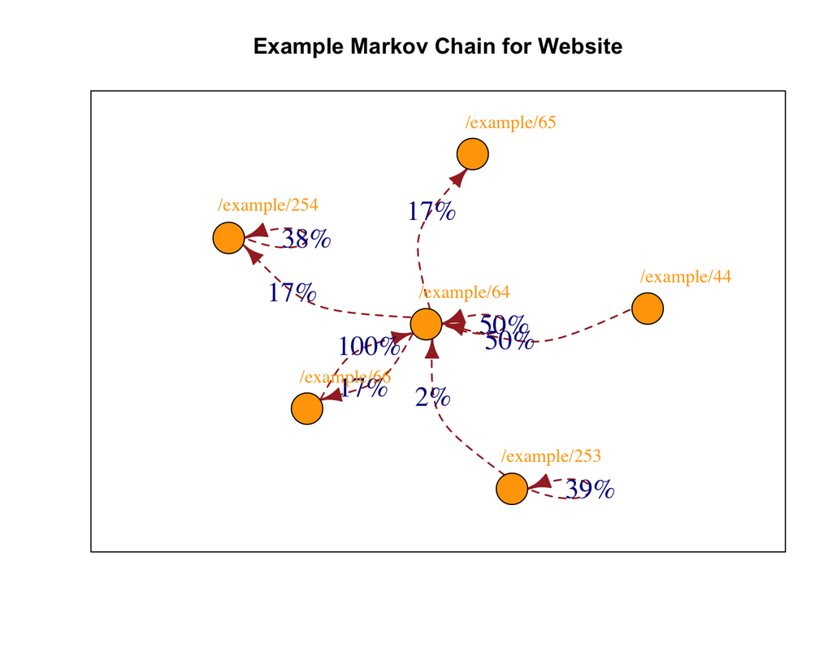

## Github - hosting the model

## Upload to Github

OpenCPU allows webhooks to Github: updates the model everytime you push to Github!

Create a small custom package with the model data and the function to predict pageviews

```r
predictMarkov <- function(pageview_names) {
  ## model loaded on package load
  states <- invisible(clickstream::states(model))
  pv_n <- pageview_names[pageview_names %in% states]
  startPattern <- new("Pattern", sequence = pv_n)
  predict <- predict(model, startPattern)

  list(page = predict@sequence,
       probability = predict@probability)
}
```

## Github package

My Github package using [this function is here](https://github.com/MarkEdmondson1234/predictClickOpenCPU)

[figure not shown]

## OpenCPU - turning R into an API

## Calling OpenCPU

Test your OpenCPU calls here: https://public.opencpu.org/ocpu/test/

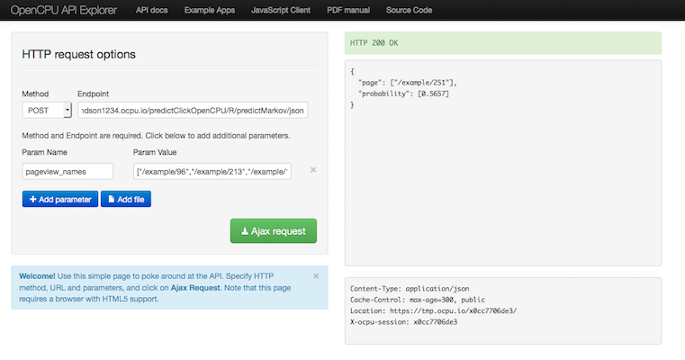

## Google Tag Manager - using the model

## GTM collecting model data - write cookie

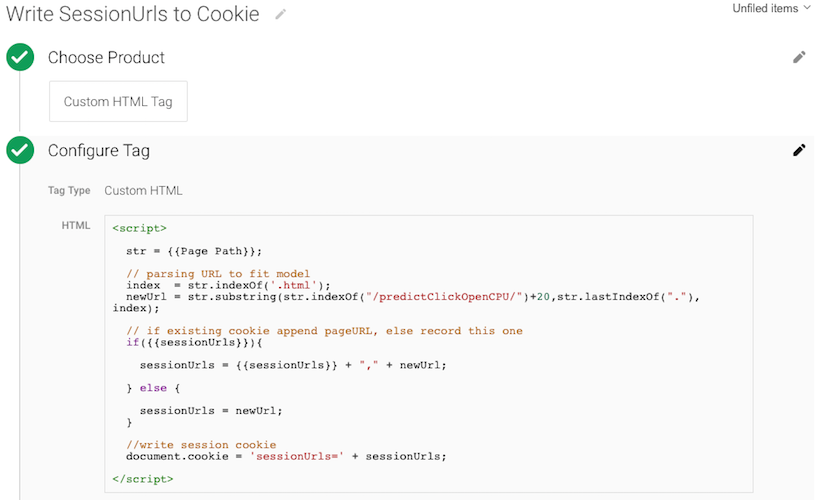

## GTM collecting model data - read cookie

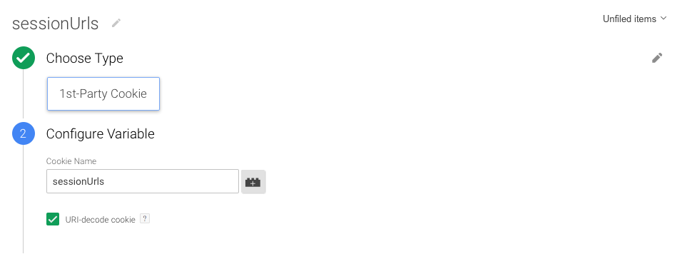

## GTM calling OpenCPU

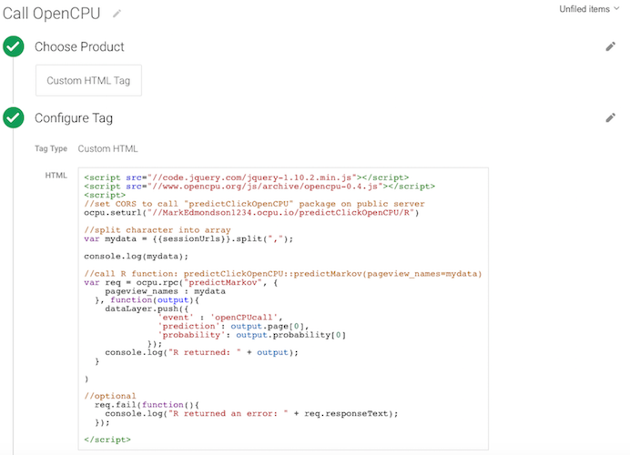

## GTM DataLayer

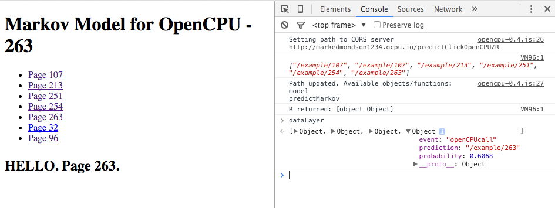

## GTM Using DataLayer setup

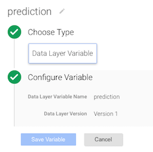

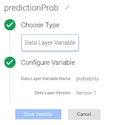

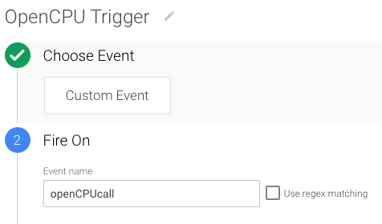

## GTM Using Prediction

Hopefully you can think of something better than a popup…

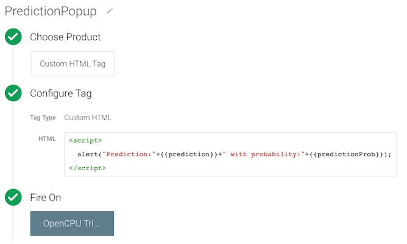

## Demo

[Demo website](http://code.markedmondson.me/predictClickOpenCPU/example/107.html)

## Next steps

- Add business logic to model:
  - Should the model predict where users go if its a bad user path?
- Would real-time data make the predictions better?
- Use your own server for OpenCPU (or look at Domino data labs / yHat paid services)
- Content recommendation just one example of this infrastructure - what else?

## Thank You

Questions?

- Say hello on Twitter: [@HoloMarkeD](http://twitter.com/HoloMarkeD)
- Read my blog: http://markedmondson.me
- Presentation will be on the IIH Nordic Blog: http://iihnordic.dk/blog
- Code and examples will be at http://code.markedmondson.me/predictClickOpenCPU/